# Rapport 2014 - version FEDORU

# 4 Description de l’offre de soins

La proposition ici se fait autour de 4 points (représentant chacun une partie de rapport) :

# 5 le ‘préambule’

```
En préalable à des résultats d’activité, cette partie peut donner un panorama de l’offre de soins en local, une description des dispositifs de remontées de données, une présentation d’actualités, mais doit surtout faire un point sur les données utilisées (suivi qualitatif et quantitatif).
```

1. Cartographie l’offre de soins (positionner les SU, SMUR) +/- organisation des soins (ex : PDSA)
2. Possibilité de rappeler quelques éléments de contexte démographique régional et les chiffres clés de la santé en région
3. Point sur le fonctionnement du concentrateur régional : organisation, flux de données (schéma type ?)
4. Exhaustivité des données urgences
- Nombre de SU transmettant des données / Nombre total de SU
  - nombre de SU transmettants des RPU: 15
  - nombre de SU ne transmettant pas: 1
  - taux d’exhaustivité: 94 %
- Nombre total de RPU / Nb total de passages SRVA (Serveur de veille et d’alerte): NA
- Nombre total de RPU / Nb total de passages SAE (Statistique annuelle des établissements de santé) (suivant disponibilité): 84 % (NOTE le nombre de passages déclarés est celui indiqué par les données SAE 2013)
- Exhaustivité quantitative régionale (NB de RPU/Nb de passages x Nb SU transmettant des RPU/Nb total SU): 79 %.
2. Qualité des données urgences
- Nombre de logiciel différents utilisés dans la région.
- Graphique en araignée du taux de complétude (% donnée manquante) (après correction données aberrantes) des variables RPU, au moins sexe, âge, durée séjour, ccmu, orientation, code diag principal, motif de recours.

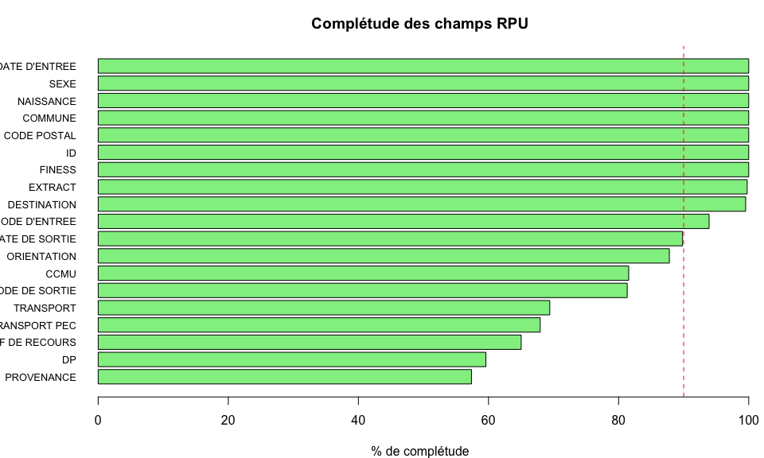

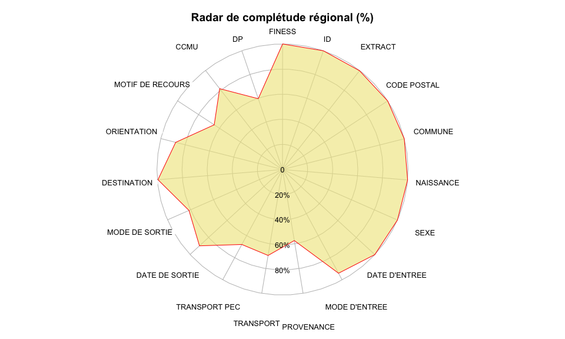

- Critères de cohérence :
- % CCMU 4 et 5 sortie externe.

#### 5.0.0.1 0.09

#### 5.0.0.2 % de CCMU 4 et 5 renvoyé à domicile: 0.09 %

```
- % Diagnostic hors thésaurus SFMU
- % âge > 18 ans dans SU pédiatriques.
- % diag féminin chez homme et inverse
```

4. Les travaux de la FEDORU et les travaux nationaux

# 6 le tableau récapitulatif dénommé “Chiffres clefs”

Parfois en début de rapport, parfois en fin, c’est une partie courte et synthétique présentant, sous forme de chiffres clefs, les grands déterminants de l’activité. Choix d’un titre commun.

**CORE [C]** obligatoire **SUPPLEMENTAL [S]** facultatif

Analyse sur la période:

- du 2014-01-01
- au 2014-12-31
- soit 365 jours

## 6.1 Nombre de SU

(nombre de SU pédiatriques, nombre de SU polyvalents, nombre SU adultes) [C]

- Nombre de SU: 16

### 6.1.1 Nombre de SU publics / privés [C]

- nombre de SU dans le secteur public: 12
- nombre de SU dans le secteur privé: 4

# 7 Les chiffres clés de l’activité des services d’urgences

## 7.1 Recueil des données

sur 2 colonnes :

## 7.2 %(N) public/privé [C]

Possiblement polémique. Pour l’instant on décide de ne pas le mettre.

- nombre de RPU publics: 343829 (82.51 %)
- nombre de RPU privés: 72904 (17.49 %)

## 7.3 Patients

## 7.4 SEXE

- %(N) Femme [C] __47.78 %__ (199 110)
- %(N) Homme [C] __52.22 %__ (217 617)

## 7.5 AGE

- % (N) < 1 an [C] __3.69 %__ (15376)
- %(N) < 18 ans [C] __28.61 %__ (119213)
- %(N) >= 75 ans [C] __13.74 %__ (57271)
- Age moyen[C]: **38.03 ans**.
- age moyen des hommes [S] 35.93 ans.
- age moyen des femmes [S] 40.31 ans.

### 7.5.1 Taux de recours (définition FEDORU) régional aux urgences. [S]

Utilisation des données INSEE qui collent le plus à la période d’étude (projections ou données consolidées)

### 7.5.2 % de patients ne venant pas de la région (étranger compris)

## 7.6 ARRIVÉE

### 7.6.1 % sur activité les jours de WE [S]

= ((Nbsam+NbDim/2)-(sommeNbJourSEm/5))/ ((Nbsam+NbDim/2)*100 [Limousin]

4.52 % d’activité supplémentaire le WE.

NB: le calcul ne tient pas compte des jours fériés (à faire).

## 7.8 Durées de passage

- durée moyenne de passage 155 mn.
- écart-type: 171.59 mn.
- médiane: 109 mn.
- nombre de passages > 4 heures: 69521 (18.69 %).

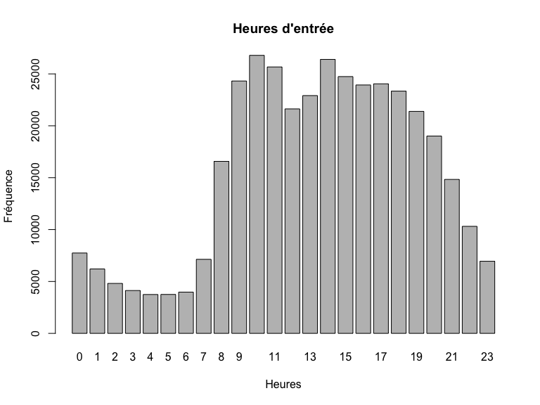

[output not shown]

### 7.8.1 % passages nuit (définition FEDORU) [C]

nombre de passages dont l’admission s’est effectuée sur la période [20h00 - 7h59] divisé par l’ensemble des passages

24.74 % (N = 92610)

### 7.8.2 % passages nuit profonde (définition FEDORU) [C]

nombre de passages dont l’admission s’est effectuée sur la période [00h00 - 7h59] divisé par l’ensemble des passages

11.09 % (N = 41500)

## 7.9 Mode de transport

### 7.9.1 %(N) d’arrivée perso [S]

72.16 % (N = 208 771)

### 7.9.2 %(N) d’arrivée SMUR [S]

0.93 % (N = 2 702)

### 7.9.3 %(N) d’arrivée VSAB [S]

10.35 % (N = 29 954)

### 7.9.4 %(N) d’arrivée Ambulance [S]

15.94 % (N = 46 112)

## 7.10 Gravité (CCMU)

### 7.10.1 %(N) CCMU 1 et 2 [C]

84.45% (n = 286979)

### 7.10.2 %(N) CCMU 4 et 5 [C]

1.28% (n = 4341)

### 7.10.3 %(N) Médico-chir [C]

### 7.10.4 %(N) Traumato [C]

### 7.10.5 %(N) Psy [C]

0.38% (n = 1307)

## 7.11 Durée de présence

### 7.11.1 Durée de séjour (hors UHCD):

moyenne +/- ET ; médiane (IQR) [C]

- moyenne: 155 mn
- écart-type: 171.59 mn
- médiane: 109 mn
- IQR: 146 mn

### 7.11.2 % (N) passages ayant durée attente > 1 heure [S]

Pas calculable en Alsace :-(

### 7.11.3 % (N) passages durée séjour > 4h [S]

18.69% (n = 69521)

## 7.12 Mode de sortie

### 7.12.1 % (N)Externe [C]

75.5 % (N = 255 852)

### 7.12.2 % (N)Hospitalisation [C]

22.72 % (N = 76 999)

### 7.12.3 % (N)Transfert [C]

1.78 % (N = 6 025)

### 7.12.5 % (N)Décès [C]

0.01% (n = 26)

# 8 les résultats régionaux

partie centrale du rapport dans laquelle tous les résultats d’activité sont présentés dans le déroulement d’une trame. Le principe est de passer en revue les variables du RPU (communes à tous normalement), d’en proposer une exploitation si elles présentent un intérêt, puis de proposer quelques croisements associés à chaque variable s’ils semblent pertinents (présence d’un bloc ‘croisement’ spécifique dans chaque partie ci dessous).

## 8.1 Volume global d’activité, cumul de passages

#### 8.1.0.1 historique du nombre de passages

#### 8.1.0.2 [1][2] par année et de la moyenne quotidienne du nombre de passages

Graphe avec 2 axes des abcisses:

- total par année
- moyenne quotidienne par année

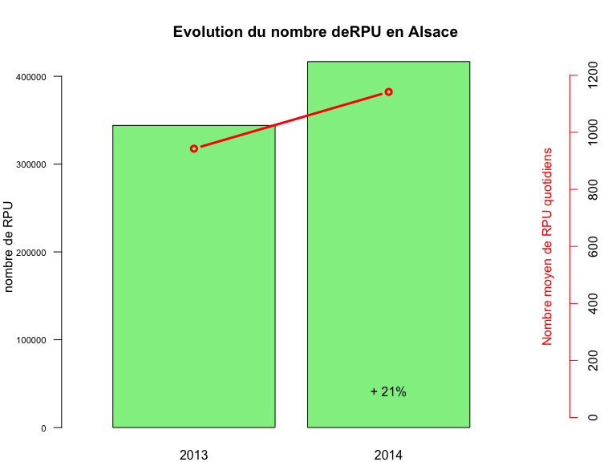

- nombre de passages en 2014: 416 733 soit en moyenne 1142 par jour.

#### 8.1.0.3 [3] % d’augmentation annuelle sur les années disponibles

% de variation 2014/2013 = 21.12 %

croisements :

#### 8.1.0.4 [4][5] nombre de passages et % par type de structures (CH, CHU, privé), année N

On utilise le fichier **Hopitaux_Alsace2.csv** qui comporte les informations suivantes:

- nom de la structure
- aabréviation pour lesRPU
- FINESS géographique
- FINESS juridique
- Groupe juridique (ex. GHSV)
- Territoire de santé
- Zone de proximité
- type
- statut
- nombre total de lits
- nombre de lits de chirurgie
- nombre de lits de médecine

Le calcul se fait après un merging de dx et de hop.

```
     2014      %
CH   "349 414" "     58"
CHU  "185 379" "     31"
PSPH " 72 904" "     12"
     "607 697" "    100"
```

#### 8.1.0.5 [6] % CH, CHU, privé sur les années disponibles

## 8.2 Caractéristique des patients : âge

- [7][8] moyenne âge +/- écart type année N

moyenne d’age: 38.03 ans, ecart-type: 27.1`ans.

- [9] répartition par tranche âge

```
[1] "ToDo"
```

```
a
    [0,5)    [5,10)   [10,15)   [15,20)   [20,25)   [25,30)   [30,35)
    51663     24738     27012     26631     28086     26827     24574
  [35,40)   [40,45)   [45,50)   [50,55)   [55,60)   [60,65)   [65,70)
    21374     22952     21162     20022     18720     17290     14635
  [70,75)   [75,80)   [80,85)   [85,90)   [90,95)  [95,100) [100,105)
    13772     15707     17692     14385      8076      1147       232
[105,110) [110,115) [115,120]
       16        15         1
```

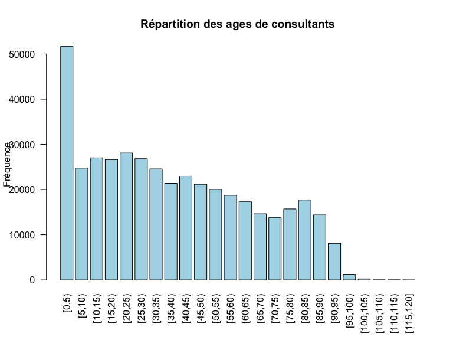

- [10] pyramide des âges des patients accueillis aux urgences année N

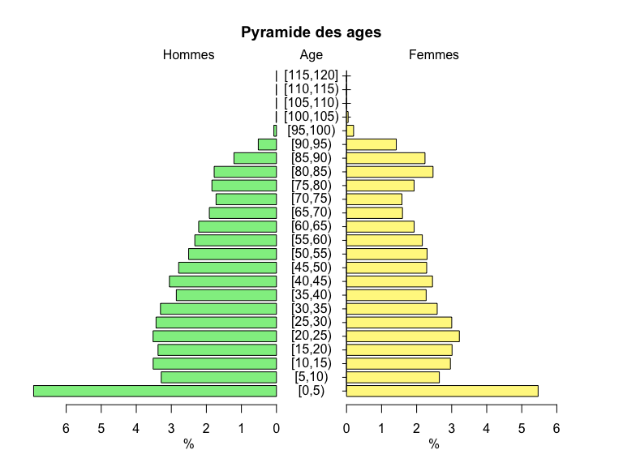

```
## [1] 5.1 4.1 4.1 2.1
```

- croisements :
- [11] sexe-moyenne âge femme/homme, année N

```
##  F  M     I
## 40 36 NA 26
```

- [12] proportion des âge extrêmes (moins de 1 an, plus de 90 ans) par mois, année N

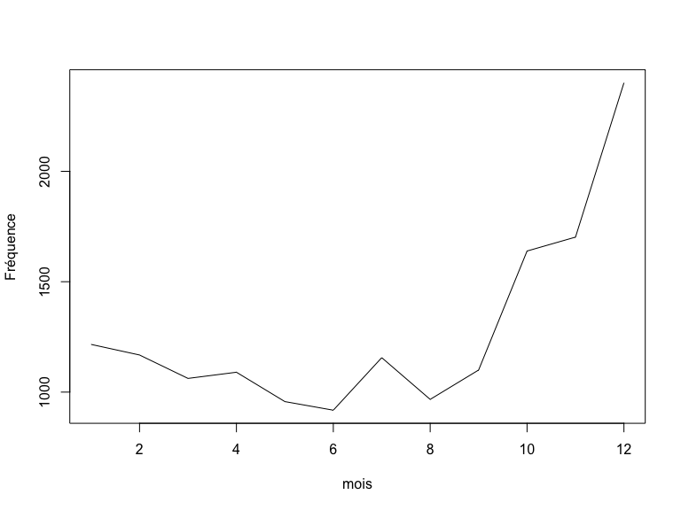

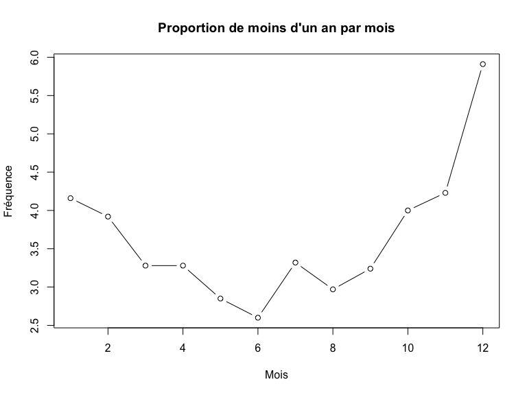

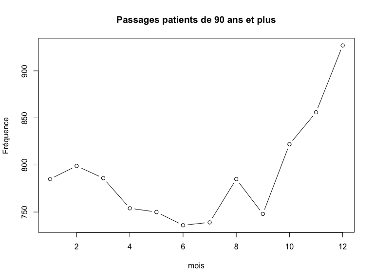

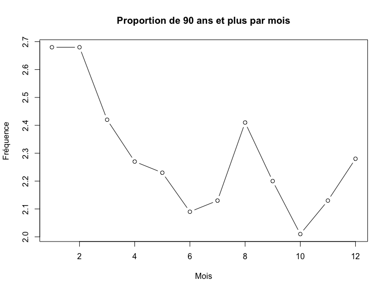

## 8.3 Caractéristique des patients : sexe

- [13] répartition en fonction du sexe année N

```
##
##      F      M             I
## 199110 217617      0      6
```

- [14] sex ratio, année N

sex-ratio = 1.09

- croisements :
- [15] sex ratio H/F par classe d’âge, année N

```
##     [0,5)    [5,10)   [10,15)   [15,20)   [20,25)   [25,30)   [30,35)
##      1.27      1.24      1.19      1.12      1.09      1.14      1.28
##   [35,40)   [40,45)   [45,50)   [50,55)   [55,60)   [60,65)   [65,70)
##      1.26      1.25      1.22      1.09      1.08      1.15      1.20
##   [70,75)   [75,80)   [80,85)   [85,90)   [90,95)  [95,100) [100,105)
##      1.09      0.96      0.72      0.54      0.37      0.37      0.21
## [105,110) [110,115) [115,120]
##      0.60      2.75        NA
```

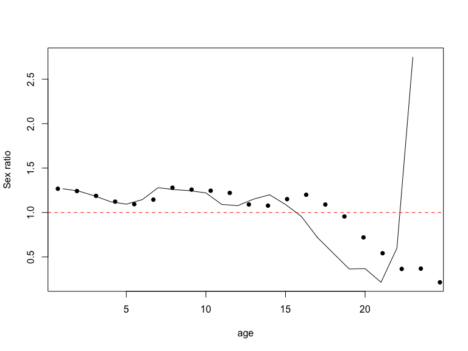

- [16] taux de masculinité

0.52

## 8.4 Provenance géographique des patients

- population régionale (INSEE)
- provenance région / hors région / étranger, année N
- cartographie des pourcentages d’activité que représentent les passages de patients provenant des départements limitrophes, année N
- cartographie du nombre de passages régional en fonction du lieu de résidence du patient (code postal) année N
- pourcentage de patient ne résidant pas dans une zone postale où est installée une structure d’urgence, année N

croisements :

- cartographie des taux de recours année N
- taux de recours / âge et / sexe, année N
- évolution par mois des moyennes quotidiennes de passages des populations région / hors région / étranger, année N

## 8.5 Arrivée aux urgences

- Moyenne quotidienne du nombre de passages par mois (basée sur la date d’admission) année N

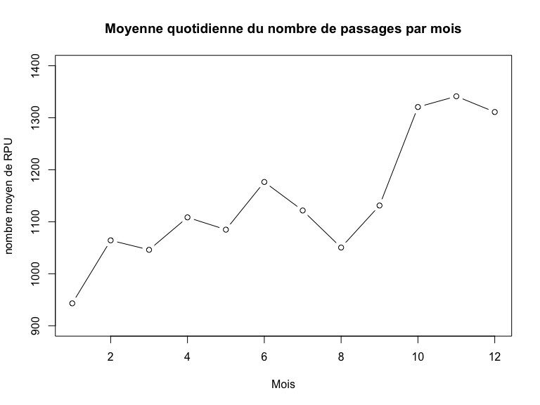

- Nombre de passages par semaine (basée sur la date d’admission) année N (positionner les vacances scolaires de la zone concernée)

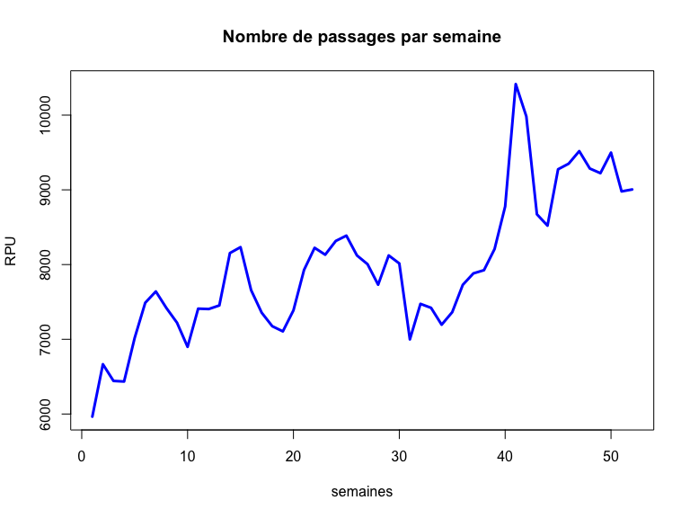

- Moyenne quotidienne du nombre de passages par jour de semaine (basée sur la date d’admission), année N
- Répartition semaine/week-end (basée sur la date d’admission), année N
- Moyenne quotidienne du nombre de passages par « tranche d’heure » d’entrée , année N
- Pourcentage du nombre de passages par heure d’entrée et de sortie, année N
- Répartition jour/nuit (%), année N
- Nombre de passages et % réalisés durant les horaires PDS

croisements :

- Différentiel d’activité en % été/hiver (pourcentage de variation du nombre de passages entre l’été (ou l’hiver) et le reste de l’année) par - - type de SU (adulte, pédia, polyvalent)
- % de catégorie d’âge (pédia, âge moyen, géria) en fonction de la tranche d’heure d’entrée, année N
- % de classe d’âge (pédia, âge moyen, géria) en fonction de l’heure d’entrée, année N
- Taux d’hospitalisation et taux de retour à domicile en fonction de l’heure d’entrée, année N
- % du type de recours (trauma, psy, medico chir) en fonction de l’heure d’entrée, année N
- % du mode de transport à l’entrée (VSAV, SMUR, AP,…) en fonction de l’heure d’entrée, année N
- Moyenne quotidienne du nombre de passages par semaine, (basée sur la date d’admission) en fonction du type de SU (polyvalent, pédia, adulte), année N

## 8.6 Mode de transport à l’arrivée aux urgences

- Répartition des modes de transport (à l’arrivée aux urgences), année N, évolution

croisements :

- Mode de transport (à l’arrivée aux urgences) par département
- Mode de transport (à l’arrivée aux urgences) par type de structure (CH, CHU, privé)
- Mode de transport (à l’arrivée aux urgences) par tranche d’âge
- Mode de transport (à l’arrivée aux urgences) par CCMU regroupé ([1;2] ; 3 ; [4;5])

## 8.7 Gravité

- répartition CCMU par regroupement ([1;2] ; 3 ; [4;5]; D; P), année N

croisements :

- pourcentage de CCMU 1 et 2 par tranche d’âge, année N
- pourcentage de CCMU 4 et 5 par tranche d’âge, année N

## 8.8 Motif de recours

```
- Nombre de passages par motif, année N
```

## 8.9 Pathologie

- répartition par type d’urgences (med/chir, traumato, psy, toxico, autre), année N
- répartition par entêtes chapitre CIM 10, année N
- répartition par disciplines, année N
- répartition par diagnostic principal (top 10), année N
- répartition par diagnostic principal (top 5) en fonction du type d’urgences (med/chir, traumato, psy, toxico, autre), année N

croisements :

```
- Type d’urgences (med/chir, traumato, psy, toxico, autre) en fonction de la classe d’âge (pédia, âge moyen, géria), année N
```

- TOP 10 diagnostic principal en fonction du sexe, année N

## 8.10 Temps de passage

- Temps de passage moyen +/- ET et médian (IQR), année N
- Répartition des passages par durée de passage en classe
- Pourcentage cumulé des temps de passage, année N

Croisements :

```
- Temps de passage médian en fonction de la classe d’âge (pédia, âge moyen, géria), année N
```

- Temps de passage médian par type de structure (CH, CHU, privé), année N
- Temps de passage médian par type de SU (polyvalent / ped/ adulte), année N
- Temps de passage médian selon catégories de nombre de passage annuel dans les SU, année N
- Temps de passage médian en fonction du mode d’entrée année N
- Temps de passage médian en fonction de CCMU (CCMU1, CCMU4&5), année N
- Temps de passage médian en fonction du sexe, année N
- Temps de passage médian en fonction du type d’urgences (med/chir, traumato, psy, toxico, autre), année N
- TOP 10 diagnostic principal pour lequel le temps de passage médian est le plus long / le plus court, année N
- Temps de passage médian en fonction de l’orientation du patient, année N
- Temps de passage médian en fonction de l’heure d’entrée et de l’heure de sortie, année N

## 8.11 Orientation

- Moyenne quotidienne du nombre de passages en fonction de l’orientation, année N

```
##  CHIR FUGUE   HDT    HO   MED  OBST   PSA   REA   REO    SC  SCAM    SI
##  30.5   1.6   1.2   1.1  66.7   1.3   9.3   3.8   4.6   5.6   1.9   8.2
##  UHCD
##  95.6
```

```
##  CHIR FUGUE   HDT    HO   MED  OBST   PSA   REA   REO    SC  SCAM    SI
## 11133   303   113    34 24340   131  3393  1346  1636  2033   526  3006
##  UHCD
## 34910
```

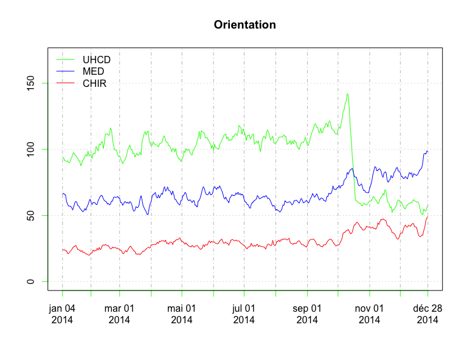

croisements :

- Moyenne quotidienne du nombre d’hospitalisations en fonction de la classe d’âge (pédia, âge moyen, géria), année N
- Taux d’hospitalisation en fonction de jour/nuit et âge, année N
- Top 5 des disciplines pathologiques pour lesquelles le taux d’hospitalisation est le plus fort, année N
- Top 5 des disciplines pathologiques pour lesquelles le taux de retour à domicile est le plus fort, année N
- Cartographie du taux de retour à domicile en fonction du lieu de résidence du patient (code postal) année N
- Nombre de décès par semaine, année N

## 8.12 les analyses par filière

focus sur une sous déclinaison de l’activité (pathologies traceuses ou traits caractéristiques de la patientèle)

#### 8.12.0.1 AVC : (définition FEDORU)

- Nombre de passages AVC urgences, année N
- Nombre de passages AVC urgences, déclinaison par département, établissement, année N
- Moyenne quotidienne, année N
- Age moyen, année N
- Répartition par classe âge en pourcentage, année N
- Répartition par sexe en pourcentage, année N
- TOP 5 pourcentage par code CIM 10, année N
- Répartition we/semaine en pourcentage, année N
- Répartition par tranche heure en pourcentage, année N
- Répartition par orientation en pourcentage, année N
- Temps de passage médian, année N

# 9 Les chiffres clés de l’activité gériatrique des services d’urgences (plus de 75 ans)

## 9.1 RECUEIL DES DONNÉES

- Nombre de passages dans l’année: 54310
- Moyenne quotidienne de passage: 148.79 passages/j
- Taux d’urgences gériatriques (Nb RPU Géria/ Nb RPU global)*100: 13.03 %
- TODO: % d’évolution par rapport à l’année N-1(données SAE pour ceux qui n’ont pas d’historique RPU fiable et permettant la comparaison, préciser l’origine des données)

## 9.2 PATIENTS

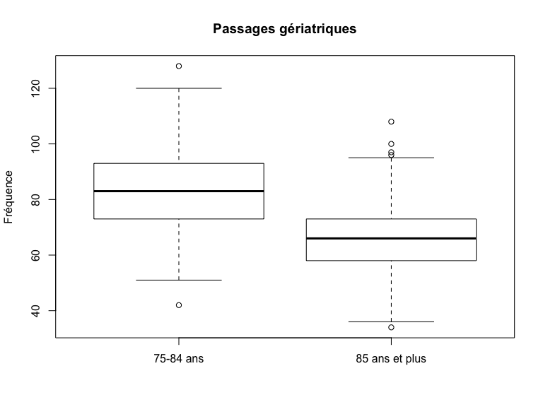

- Sex ratio: 0.64
- Pyramide des âges (âge par année, borne supérieure toujours exclue)
- Par sous classe d’âge (GT1:2 classes, moins de 85 et 85 ans et plus): ￼- Nombre de passages ￼- Moyenne quotidienne de passage ￼- Sex ratio

## 9.3 ARRIVÉE

- % passages la nuit: 22.35 % (N = 12140)
- % passages en horaire de PDS: NA % (N = NA)
- % d’arrivées Moyen perso: 20.17 % (N = 10953)
- % d’arrivées SMUR: 1.2 % (N = 654)
- % d’arrivées VSAV: 11.98 % (N = 6505)
- % d’arrivées ambulance privée: 37.91 % (N = 20587)
- % réponses manquantes:

NB : commentaire possible pour expliquer que la somme des 4 pourcentages ci dessus ne fait pas 100 %

- % CCMU 1: 4.27 % (N = 2318)
- % CCMU 4 et 5: 3.16 % (N = 1718)

## 9.4 DIAGNOSTIC PRINCIPAL

- % Médico-chirurgical, dont :
  - % cardio vasculaire
  - % neuro
  - % digestif
  - % respiratoire
- % Traumatologique
- % Psychiatrique
- % Toxicologique
- % Autres recours

## 9.5 DURÉE

```
##        NA  Mutation Transfert  Domicile     Décès
##        NA       219       318       216        NA        NA
```

```
##        NA  Mutation Transfert  Domicile     Décès
##        NA       200       250       176        NA        NA
```

```
##
##  Welch Two Sample t-test
##
## data:  passages75$duree by passages75$DEVENIR
## t = -4.1, df = 38419, p-value = 0.00003634
## alternative hypothesis: true difference in means is not equal to 0
## 95 percent confidence interval:
##  -11.7  -4.2
## sample estimates:
## mean in group Domicile     mean in group Hosp
##                    216                    224
```

```
## [1] 0.000036
```

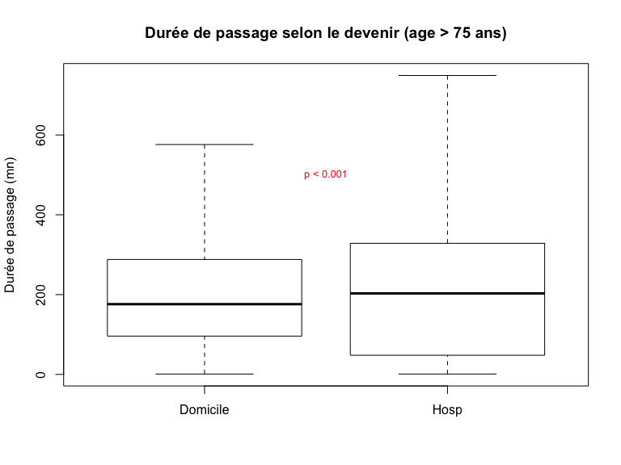

- Durée moyenne de passage (HORS UHCD) : 221 minutes
- Durée médiane de passage (HORS UHCD) : 191 minutes
- % de passages de moins de 4h : 60.92 %
- lors d’une hospitalisation post-urgences (hospitalisation = mutation + transfert): 224.04 minutes.
- lors d’un retour au domicile: 216.09 minutes.

## 9.6 MODE DE SORTIE

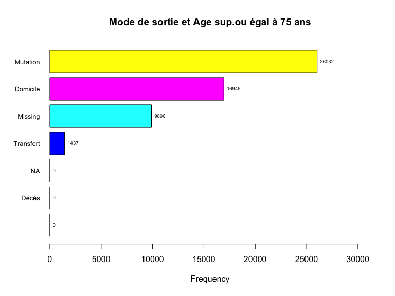

```
## pop75$MODE_SORTIE :
##           Frequency   %(NA+)   %(NA-)
## Mutation      26032     47.9     58.6
## Domicile      16945     31.2     38.2
## NA's           9896     18.2      0.0
## Transfert      1437      2.6      3.2
## NA                0      0.0      0.0
## Décès             0      0.0      0.0
##                   0      0.0      0.0
##   Total       54310    100.0    100.0
```

- % d’hospitalisation: 50.58 % (N = 27469)
- % de mutation:47.93 % (N = 26032)
- % de transfert:2.65 % (N = 1437)
- % de retour à domicile:31.2 % (N = 16945)

# 10 Définitions FEDORU

## 10.1 taux de recours (de la région ou département)

nombre de passages dans les services d’urgences (de la région ou département) de patients résidant dans une zone donnée (code postal ou commune) divisé par la population estimée de cette zone sur la période donnée.

## 10.2 pourcentage de passage nuit

nombre de passages dont l’admission s’est effectuée sur la période [20h00 - 7h59] divisé par l’ensemble des passages

## 10.3 pourcentage de passage nuit profonde

nombre de passages dont l’admission s’est effectuée sur la période [00h00 - 7h59] divisé par l’ensemble des passages

## 10.4 tranche d’âge

```
<28j;[28j-1A[;[1-5[;[5-10[;[10-15[;[15-18[;[18-30[;[30-45[;[45;65[;[65-75[;[75;85[;>85ans
```

## 10.5 sexe

M/F/I

## 10.6 « tranche d’heure » d’entrée

matinée [8h00-11h59] ; début d’après midi [12h00-15h59] ; fin d’après midi [16h00-19h59] ; soirée [20h00-23h59] ; nuit profonde [00h00;07h59]

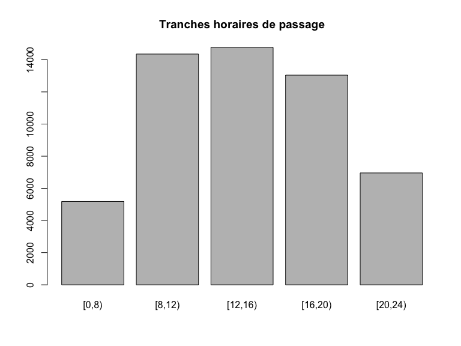

## 10.7 horaire PDS

- week end PDSA: du samedi 12h00 au lundi 07h59
- en semaine: du lundi au vendredi de [20h00 - 07h59] le lendemain
- jour férié: de 00h00 à 23h59
- pont PDSA: de 00h00 à 23h59

Les ponts PDSA sont ceux qui sont qualifiés comme tel par l’ARS et qui génère à ce titre le mise en place d’une régulation PDSA sur cette période. Si un pont PDSA, ou un jour férié survient un vendredi, le samedi matin suivant sera dès lors intégré à l’activité PDSA.

## 10.8 durée de passage en classe

2 types de regroupements :

- moins de 4 heures ; 4 heures et plus
- moins d’une heure ; entre 1 et 2 heures ; de 2 à 4 heures ; de 4 à 8 heures ; de 8 à 12 heures ; entre 12 et 72 heures ; (bornes supérieures exclues)

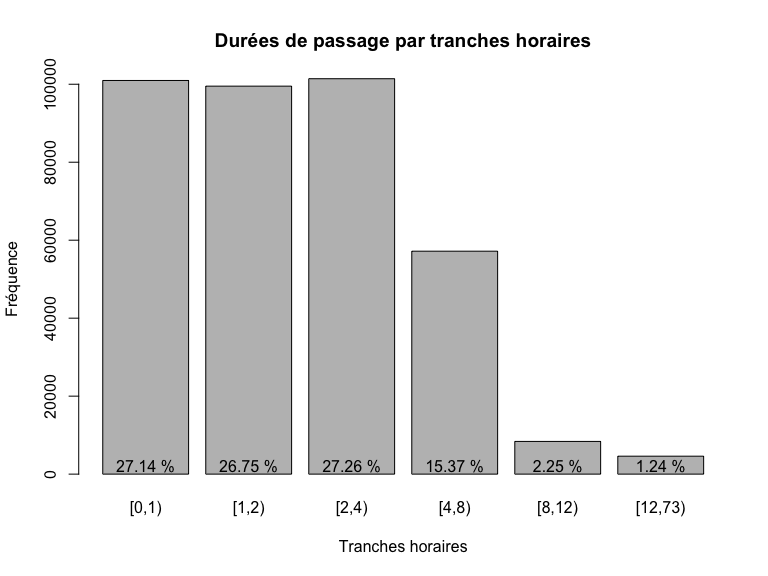

# 11 Résumé des chiffres clé

```
             anc    periode.debut      periode.fin          n.jours
        2014.000        16071.000        16435.000          365.000
        n.su.ped     n.su.adultes n.su.polyvalents     n.su.publics
           1.000            2.000           13.000           12.000
     n.su.prives            n.rpu    mean.rpu.quot            n.pub
           4.000       416733.000         1141.734       343829.000
           n.prv            p.pub            p.prv          p.femme
       72904.000            0.825            0.175           47.779
         p.homme         n.femmes         n.hommes   tx.masculinite
          52.221       199110.000       217617.000            0.522
        n.inf1an      n.supegal90         p.inf1an        n.inf18an
       15376.000         9487.000            0.037       119213.000
       p.inf18an    n.supegal75an    p.supegal75an         mean.age
           0.286        57271.000            0.137           38.027
          sd.age       median.age       mean.age.h       mean.age.f
          27.103           34.000           35.935           40.313
```

# 12 Temps de calcul

```
##    user  system elapsed
##   100.6     2.5   103.6
```